# Lab 7

Key

11/06/2018

# Data prep

In the code chunk below, load the appropriate libraries and import the elemapi dataset.

```r
library(tidyverse)
library(here)
library(rio)
theme_set(theme_minimal())

d <- import(here("data", "elemapi.sav"),
            setclass = "tbl_df") %>%
  characterize()
```

Knit the file immediately. If you get an error from the chunk below, keep working until your data are loaded correctly (and get help if you need it).

```r
head(d)
```

```
## # A tibble: 6 x 21
##    snum  dnum api00 api99 growth meals   ell yr_rnd mobility acs_k3 acs_46
##   <dbl> <dbl> <dbl> <dbl>  <dbl> <dbl> <dbl> <chr>     <dbl>  <dbl>  <dbl>
## 1   906    41   693   600     93    67     9 No           11     16     22
## 2   889    41   570   501     69    92    21 No           33     15     32
## 3   887    41   546   472     74    97    29 No           36     17     25
## 4   876    41   571   487     84    90    27 No           27     20     30
## 5   888    41   478   425     53    89    30 No           44     18     31
## 6  4284    98   858   844     14    NA     3 No           10     20     33
## # ... with 10 more variables: not_hsg <dbl>, hsg <dbl>, some_col <dbl>,
## #   col_grad <dbl>, grad_sch <dbl>, avg_ed <dbl>, full <dbl>, emer <dbl>,
## #   enroll <dbl>, mealcat <chr>
```

# Scenario

The state department of education in California is interested in evaluating the average gain in API scores (an accountability index) by lunch category. Each row in this dataset represents a school.

Use ggplot to visualize the relation between API 99 and API 00 by meal category.

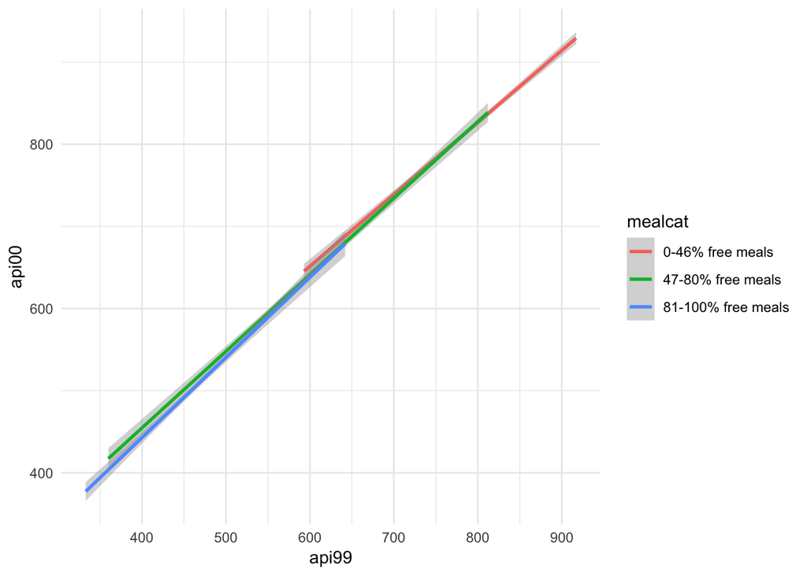

```r
ggplot(d, aes(api99, api00, color = mealcat)) +
  geom_smooth(method = "lm")
```

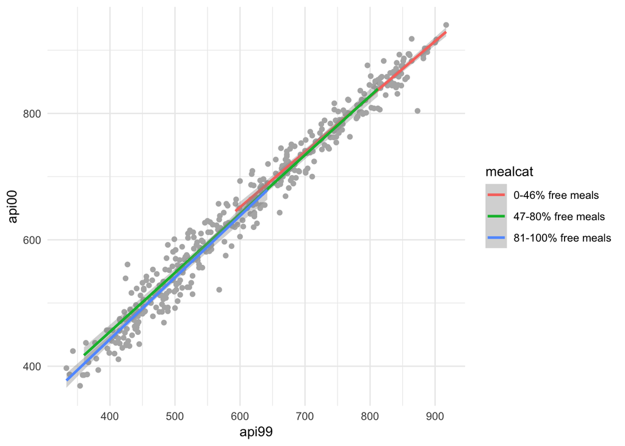

```r
ggplot(d, aes(api99, api00)) +
  geom_point(color = "gray70") +
  geom_smooth(aes(color = mealcat),
              method = "lm")
```

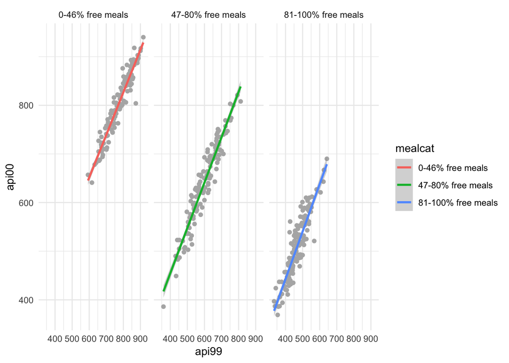

```r
ggplot(d, aes(api99, api00)) +
  geom_point(color = "gray70") +
  geom_smooth(aes(color = mealcat),
              method = "lm") +
  facet_wrap(~mealcat)
```

In the space below, explain if it appears that an interaction is justified or not

Overall, the lines appear rather parallel, so fitting an interaction may be overfitting the data.

Fit the following model in the code chunk below. Fit the model with schools between 47-80% as the reference group.

$$api_{2000_i} = b_0 + b_1(api_{1999_i}) + b_2(meal_{cat_i}) + e$$

```r
d <- d %>%
  mutate(mealcat = factor(mealcat),
         mealcat = relevel(mealcat, ref = "47-80% free meals"))

m1 <- lm(api00 ~ api99 + mealcat, d)
summary(m1)
```

```
##
## Call:
## lm(formula = api00 ~ api99 + mealcat, data = d)
##
## Residuals:
##     Min      1Q  Median      3Q     Max
## -91.200 -15.826   1.051  14.405  89.999
##
## Coefficients:
##                            Estimate Std. Error t value Pr(>|t|)
## (Intercept)                86.96847   10.29409   8.448 5.69e-16 ***
## api99                       0.92345    0.01685  54.817  < 2e-16 ***
## mealcat0-46% free meals     2.06091    4.22279   0.488  0.62579
## mealcat81-100% free meals -10.28067    3.71963  -2.764  0.00598 **
## ---
## Signif. codes:  0 '***' 0.001 '**' 0.01 '*' 0.05 '.' 0.1 ' ' 1
##
## Residual standard error: 24.13 on 396 degrees of freedom
## Multiple R-squared:  0.9715, Adjusted R-squared:  0.9712
## F-statistic:  4492 on 3 and 396 DF,  p-value: < 2.2e-16
```

In the space below, explain why this model does or does not correspond with the plots you displayed above.

This model does not correspond to the visualizations we produced above because it is a parellel slopes model, while the plots are displaying the interaction.

Is the intercept meaningful in `m1`? Why or why not?

No. The lowest possible API score appears to be right around 400, but the intercept represents the expected API 2000 score when API 1999 is zero.

In the code chunk below, re-fit the model to make the intercept meaningful.

```r
d <- d %>%
  mutate(api99_c = api99 - mean(api99))

m1c <- lm(api00 ~ api99_c + mealcat, d)
summary(m1c)
```

```
##
## Call:
## lm(formula = api00 ~ api99_c + mealcat, data = d)
##
## Residuals:
##     Min      1Q  Median      3Q     Max
## -91.200 -15.826   1.051  14.405  89.999
##
## Coefficients:
##                            Estimate Std. Error t value Pr(>|t|)
## (Intercept)               650.46868    2.10956 308.343  < 2e-16 ***
## api99_c                     0.92345    0.01685  54.817  < 2e-16 ***
## mealcat0-46% free meals     2.06091    4.22279   0.488  0.62579
## mealcat81-100% free meals -10.28067    3.71963  -2.764  0.00598 **
## ---
## Signif. codes:  0 '***' 0.001 '**' 0.01 '*' 0.05 '.' 0.1 ' ' 1
##
## Residual standard error: 24.13 on 396 degrees of freedom
## Multiple R-squared:  0.9715, Adjusted R-squared:  0.9712
## F-statistic:  4492 on 3 and 396 DF,  p-value: < 2.2e-16
```

Interpret the intercept in the space below.

The intercept represents the average API 2000 score for schools who had the average API score in 1999 and had between 47-80% of students eligible for free or reduced price lunch.

In the code chunk below, extend the model above to specify meal category as a moderator of the API 1999 slope.

```r
m2 <- lm(api00 ~ api99_c + mealcat + api99_c:mealcat, d)
summary(m2)
```

```
##
## Call:
## lm(formula = api00 ~ api99_c + mealcat + api99_c:mealcat, data = d)
##
## Residuals:
##     Min      1Q  Median      3Q     Max
## -86.581 -16.033   0.496  15.341  91.887
##
## Coefficients:
##                                    Estimate Std. Error t value Pr(>|t|)
## (Intercept)                       650.57456    2.11354 307.812   <2e-16
## api99_c                             0.93228    0.02498  37.314   <2e-16
## mealcat0-46% free meals             9.86271    5.71022   1.727   0.0849
## mealcat81-100% free meals          -2.70791    6.01119  -0.450   0.6526
## api99_c:mealcat0-46% free meals    -0.05650    0.03856  -1.465   0.1436
## api99_c:mealcat81-100% free meals   0.04338    0.04351   0.997   0.3194
##
## (Intercept)                       ***
## api99_c                           ***
## mealcat0-46% free meals           .
## mealcat81-100% free meals
## api99_c:mealcat0-46% free meals
## api99_c:mealcat81-100% free meals
## ---
## Signif. codes:  0 '***' 0.001 '**' 0.01 '*' 0.05 '.' 0.1 ' ' 1
##
## Residual standard error: 24.04 on 394 degrees of freedom
## Multiple R-squared:  0.9718, Adjusted R-squared:  0.9714
## F-statistic:  2716 on 5 and 394 DF,  p-value: < 2.2e-16
```

In the code chunk below, include any other follow-up investigations you would like to help you interpret the model. Following these analyses, interpret the model as a whole in the space below the code chunk.

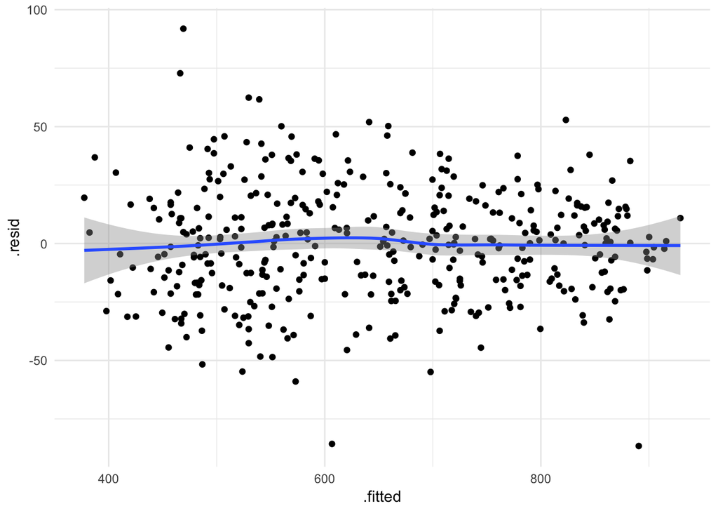

```r
ggplot(m2, aes(.fitted, .resid)) +
  geom_point() +
  geom_smooth()
```

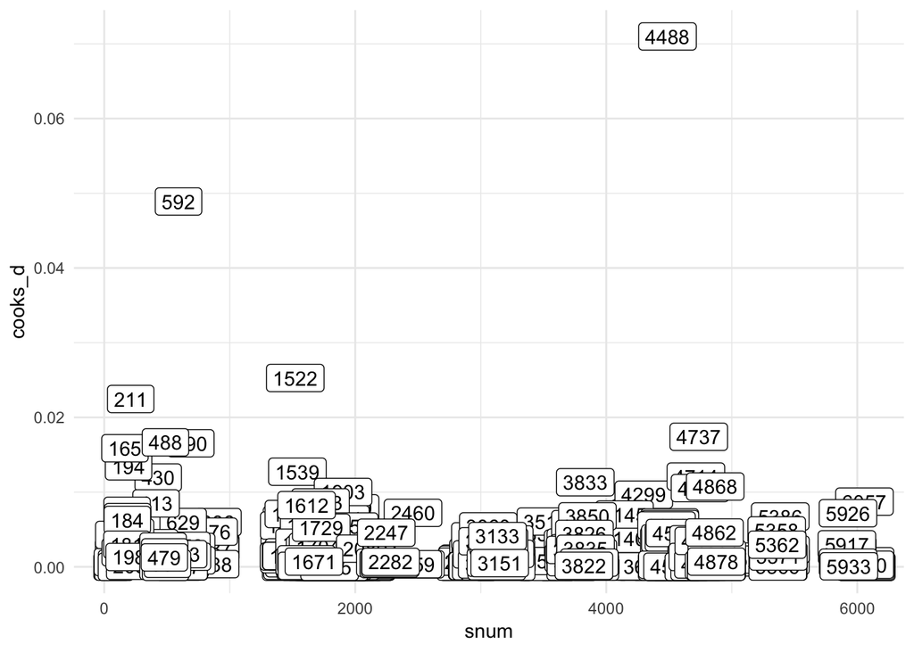

```r
d <- d %>%
  mutate(cooks_d = cooks.distance(m2))

ggplot(d, aes(snum, cooks_d)) +
  geom_label(aes(label = snum))
```

```r
confint(m2)
```

```
##                                         2.5 %       97.5 %
## (Intercept)                       646.4193251 654.72979017
## api99_c                             0.8831577   0.98139696
## mealcat0-46% free meals            -1.3636020  21.08902141
## mealcat81-100% free meals         -14.5259341   9.11011607
## api99_c:mealcat0-46% free meals    -0.1322973   0.01930268
## api99_c:mealcat81-100% free meals  -0.0421627   0.12893039
```

```r
lmSupport::modelEffectSizes(m2)
```

```
## lm(formula = api00 ~ api99_c + mealcat + api99_c:mealcat, data = d)
##
## Coefficients
##                          SSR df pEta-sqr dR-sqr
## (Intercept)     54745768.615  1   0.9959     NA
## api99_c           804501.790  1   0.7794 0.0996
## mealcat             1991.713  2   0.0087 0.0002
## api99_c:mealcat     2835.890  2   0.0123 0.0004
##
## Sum of squared errors (SSE): 227653.8
## Sum of squared total  (SST): 8073672.0
```

The model overall accounted for 97% of the variability in API scores in 2000. Schools with the average API score in 1999 with between 47-80% of students eligible for free or reduced price lunch were predicted to score, on average 650.57 API points in 2000 (95% CI: 646.42 to 654.73). Schools with the average API score in 1999 that had between 0-46% of students eligible for free or reduced price lunch were expected to have an API score in 2000 aproximately 9.86 points higher (95% CI: -1.36 to 21.09), on average, while schools with 81-100% of students eligible were expected to have an API score 2.71 points lower (95% CI: -14.53 to 9.11), on average. Neither difference was significant ($p > 0.05$) Meal category was not a significant moderator of the API99 slope. The squared semipartial correlations indicated that approximately 10% of the total variability was uniquely accounted forby API scores in 1999, while meal category and the interaction term each uniquely accounted for less than 1% of the total variability. Preliminary and post-hoc exploratory plots indicated the assumptions of the model were tenable.